# Student linear regression

Vu Duc Thanh

```
## # A tibble: 6 × 33
##   school sex     age address famsize Pstatus  Medu  Fedu Mjob     Fjob    reason
##   <chr>  <chr> <dbl> <chr>   <chr>   <chr>   <dbl> <dbl> <chr>    <chr>   <chr>
## 1 GP     F        18 U       GT3     A           4     4 at_home  teacher course
## 2 GP     F        17 U       GT3     T           1     1 at_home  other   course
## 3 GP     F        15 U       LE3     T           1     1 at_home  other   other
## 4 GP     F        15 U       GT3     T           4     2 health   servic… home
## 5 GP     F        16 U       GT3     T           3     3 other    other   home
## 6 GP     M        16 U       LE3     T           4     3 services other   reput…
## # … with 22 more variables: guardian <chr>, traveltime <dbl>, studytime <dbl>,
## #   failures <dbl>, schoolsup <chr>, famsup <chr>, paid <chr>,
## #   activities <chr>, nursery <chr>, higher <chr>, internet <chr>,
## #   romantic <chr>, famrel <dbl>, freetime <dbl>, goout <dbl>, Dalc <dbl>,
## #   Walc <dbl>, health <dbl>, absences <dbl>, G1 <dbl>, G2 <dbl>, G3 <dbl>
```

Visualize the data

History plot of G1,G2 and G3

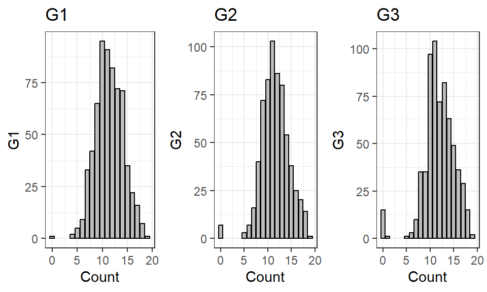

```r
g3<-df %>%
  ggplot(aes(x=G3)) +
  geom_bar(stat="count",color = "black", fill = "gray") +
  xlab('Count') + ylab('G3') + ggtitle('G3')
g2<-df %>%
  ggplot(aes(x=G2)) +
  geom_bar(stat="count",color = "black", fill = "gray") +
  xlab('Count') + ylab('G2') + ggtitle('G2')
g1<-df %>%
  ggplot(aes(x=G1)) +
  geom_bar(stat="count",color = "black", fill = "gray") +
  xlab('Count') + ylab('G1') + ggtitle('G1')
grid.arrange(g1,g2,g3, ncol=3)
```

Count plot of absences and age

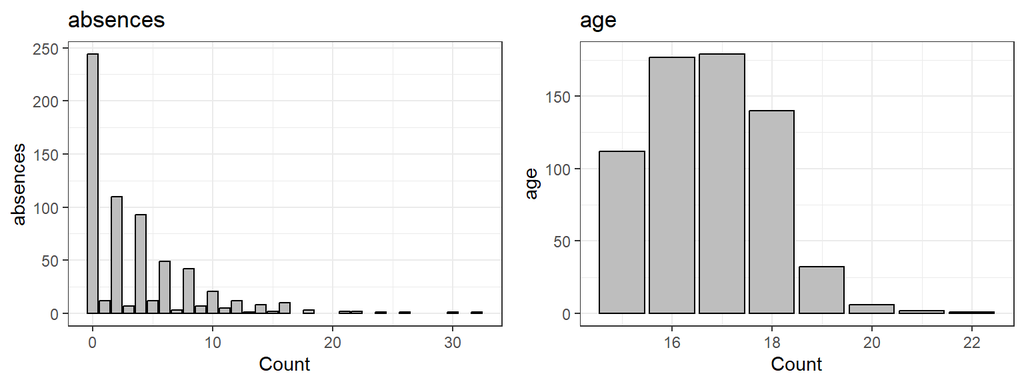

```r
ab_plot <- df %>% ggplot(aes(absences))+
        geom_bar(stat="count",color = "black", fill = "gray") +
        xlab('Count') + ylab('absences') + ggtitle('absences')
age_plot <- df %>% ggplot(aes(age))+
        geom_bar(stat="count",color = "black", fill = "gray") +
        xlab('Count') + ylab('age') + ggtitle('age')
grid.arrange(ab_plot,age_plot, ncol=2)
```

Scatter plot between absence vs G3 and age vs G3

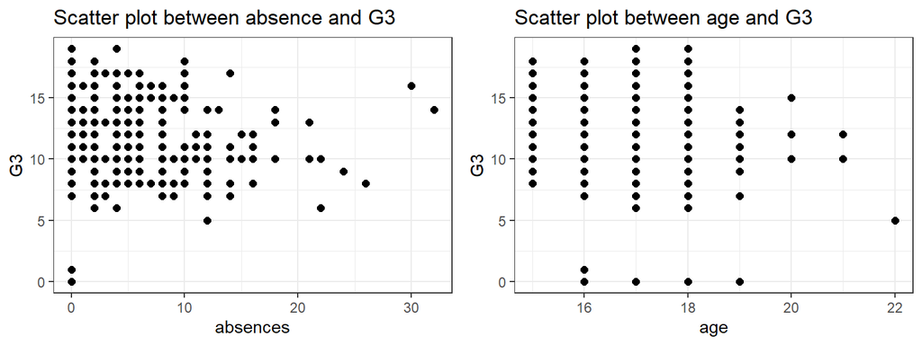

```r
p1 <- df %>% ggplot(aes(absences,G3))+
        geom_point(size = 2, color = "black") +
        xlab('absences') + ylab('G3') + ggtitle('Scatter plot between absence and G3')

p2<- df %>% ggplot(aes(age,G3))+
        geom_point(size = 2, color = "black") +
        xlab('age') + ylab('G3') + ggtitle('Scatter plot between age and G3')
grid.arrange(p1,p2, ncol=2)
```

Box plot of various features vs G3

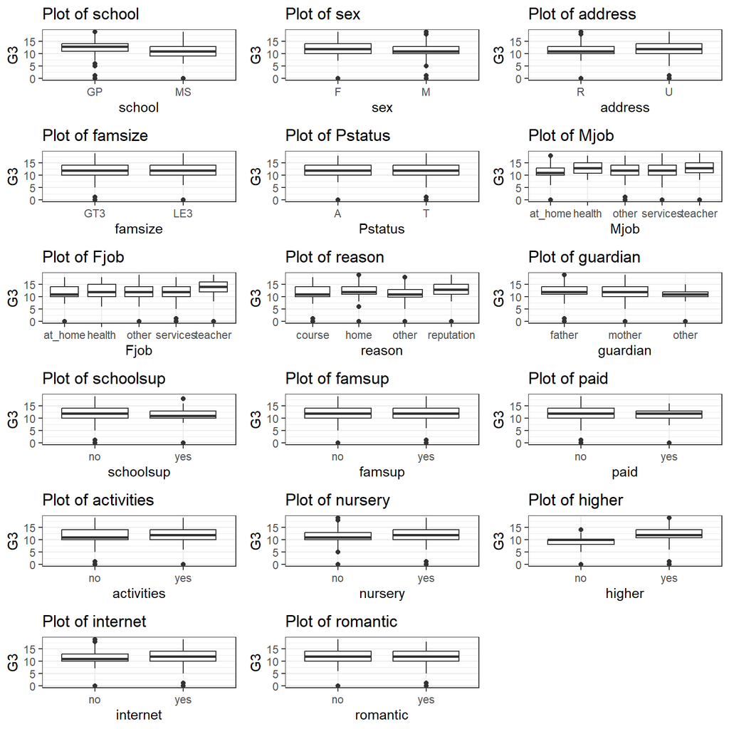

```r
library(ggplot2)
library(gridExtra)
number_cat <- c("Medu","Fedu","traveltime","studytime","failures","famrel","freetime","goout","Dalc","Walc","health")
category <- setdiff(colnames(df),c(c('age','G1','G2','G3',"absences"),number_cat))

#category <-c("school","sex","address")
plot_list <- list()


for (col in category){
    myplot <- ggplot(df,aes(x=.data[[col]],y=G3)) +
              geom_boxplot()+
              xlab(col) + ylab('G3')+
              labs(title = paste("Plot of", col))
     plot_list[[col]] <- myplot
}
grid.arrange(grobs = plot_list, ncol = 3)
```

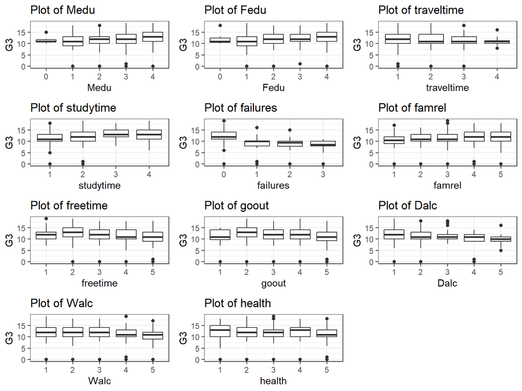

```r
library(ggplot2)
library(gridExtra)
number_cat <- c("Medu","Fedu","traveltime","studytime","failures","famrel","freetime","goout","Dalc","Walc","health")
num_df <- df[,c(number_cat,"G3")]
num_df[,number_cat]<-lapply(num_df[,number_cat],as.character)
#str(num_df)
numdf_plot <- list()

for (cat in number_cat){
    myplot <- ggplot(num_df,aes(x=.data[[cat]],y=G3)) +
              geom_boxplot()+
              xlab(cat) + ylab('G3')+
              labs(title = paste("Plot of", cat))
     numdf_plot[[cat]] <- myplot
}
grid.arrange(grobs = numdf_plot, ncol = 3)
```

Dummies encoding categorical data

```r
library(caret)

cate_df <- df[,category]
new_df <- model.matrix(~.-1, data = cate_df)

combined_df <- cbind(new_df,df[,c(number_cat,"absences","G3")])
combined_df <- subset(combined_df, select = -schoolGP)
head(combined_df)
```

```
##   schoolMS sexM addressU famsizeLE3 PstatusT Mjobhealth Mjobother Mjobservices
## 1        0    0        1          0        0          0         0            0
## 2        0    0        1          0        1          0         0            0
## 3        0    0        1          1        1          0         0            0
## 4        0    0        1          0        1          1         0            0
## 5        0    0        1          0        1          0         1            0
## 6        0    1        1          1        1          0         0            1
##   Mjobteacher Fjobhealth Fjobother Fjobservices Fjobteacher reasonhome
## 1           0          0         0            0           1          0
## 2           0          0         1            0           0          0
## 3           0          0         1            0           0          0
## 4           0          0         0            1           0          1
## 5           0          0         1            0           0          1
## 6           0          0         1            0           0          0
##   reasonother reasonreputation guardianmother guardianother schoolsupyes
```

[output cut: 27 more lines]

Building the first model including all features

```r
model1 <- lm(G3 ~ ., data = combined_df)
```

Residuals visual inspection:

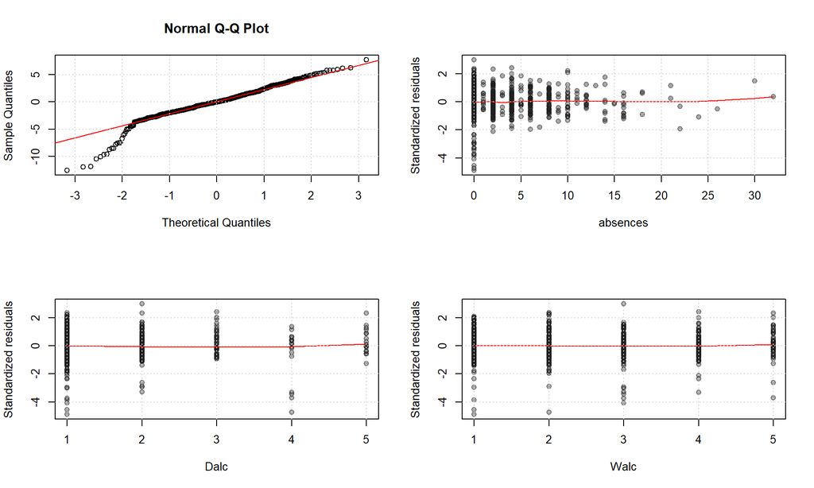

Follow-up tests for the residuals:

| Test | p-value |
| --- | --- |
| Shapiro-Wilk | 1.1113666^{-14} |
| Breusch-Pagan | 5.0831579^{-5} |

```r
shapiro.test(residuals(model1))$p.value
```

```
## [1] 1.111367e-14
```

```r
bptest(model1)$p.value
```

```
##           BP
## 5.083158e-05
```

They are not normal and heteroscedastic, so we’ll need to use White’s correction as well as adjustment for multiplicity when estimating the significance of the predictors:

```
##
## Call:
## lm(formula = G3 ~ ., data = combined_df)
##
## Residuals:
##      Min       1Q   Median       3Q      Max
## -12.6410  -1.4410  -0.0253   1.5572   7.7909
##
## Coefficients:
##                    Estimate Std. Error    t value   Pr(>|t|) Adjusted p-value
## (Intercept)       1.122e+01  1.088e+00  1.032e+01  4.100e-23              NaN
## schoolMS         -1.181e+00  2.673e-01 -4.418e+00  1.180e-05            0.002
## sexM             -6.622e-01  2.496e-01 -2.653e+00  8.177e-03            0.284
## addressU          3.291e-01  2.621e-01  1.256e+00  2.096e-01            1.000
## famsizeLE3        3.094e-01  2.453e-01  1.262e+00  2.075e-01            0.997
## PstatusT          2.128e-01  3.463e-01  6.147e-01  5.390e-01            1.000
## Mjobhealth        8.424e-01  5.367e-01  1.570e+00  1.170e-01            0.852
## Mjobother         3.910e-02  3.032e-01  1.290e-01  8.974e-01            1.000
## Mjobservices      4.044e-01  3.733e-01  1.083e+00  2.792e-01            1.000
## Mjobteacher       5.028e-01  5.024e-01  1.001e+00  3.173e-01            1.000
## Fjobhealth       -6.936e-01  7.513e-01 -9.232e-01  3.563e-01            1.000
## Fjobother        -2.102e-01  4.564e-01 -4.605e-01  6.453e-01            1.000
## Fjobservices     -6.745e-01  4.793e-01 -1.407e+00  1.599e-01            0.978
## Fjobteacher       5.672e-01  6.729e-01  8.428e-01  3.996e-01            1.000
## reasonhome        6.003e-02  2.852e-01  2.105e-01  8.333e-01            1.000
## reasonother      -4.326e-01  3.680e-01 -1.176e+00  2.402e-01            1.000
## reasonreputation  2.495e-01  2.976e-01  8.385e-01  4.021e-01            1.000
## guardianmother   -3.054e-01  2.646e-01 -1.154e+00  2.488e-01            1.000
## guardianother     3.137e-01  5.144e-01  6.098e-01  5.422e-01            1.000
## schoolsupyes     -1.396e+00  3.602e-01 -3.875e+00  1.183e-04            0.002
## famsupyes        -6.390e-02  2.268e-01 -2.818e-01  7.782e-01            1.000
## paidyes          -3.823e-01  4.619e-01 -8.277e-01  4.082e-01            1.000
## activitiesyes     1.938e-01  2.230e-01  8.689e-01  3.853e-01            1.000
## nurseryyes       -2.032e-01  2.716e-01 -7.484e-01  4.545e-01            1.000
## higheryes         1.661e+00  3.803e-01  4.369e+00  1.468e-05            0.000
## internetyes       2.707e-01  2.764e-01  9.794e-01  3.278e-01            1.000
## romanticyes      -3.949e-01  2.282e-01 -1.730e+00  8.406e-02            0.925
## Medu              3.845e-02  1.515e-01  2.538e-01  7.997e-01            1.000
## Fedu              1.651e-01  1.379e-01  1.197e+00  2.317e-01            1.000
## traveltime        5.266e-02  1.592e-01  3.308e-01  7.409e-01            1.000
## studytime         4.243e-01  1.396e-01  3.039e+00  2.478e-03            0.013
## failures         -1.335e+00  1.984e-01 -6.730e+00  3.929e-11            0.000
## famrel            1.689e-01  1.161e-01  1.455e+00  1.463e-01            0.992
## freetime         -1.539e-01  1.120e-01 -1.374e+00  1.698e-01            0.996
## goout            -4.981e-02  1.071e-01 -4.652e-01  6.419e-01            1.000
## Dalc             -1.906e-01  1.529e-01 -1.246e+00  2.131e-01            1.000
## Walc             -8.017e-02  1.186e-01 -6.760e-01  4.993e-01            1.000
## health           -1.841e-01  7.725e-02 -2.383e+00  1.750e-02            0.396
## absences         -3.627e-02  2.486e-02 -1.459e+00  1.451e-01            0.989
##
## Residual standard error: 2.668 on 610 degrees of freedom
## Multiple R-squared:  0.3579, Adjusted R-squared:  0.3179
## F-statistic: 8.947 on 38 and 610 DF,  p-value: < 2.2e-16
```

Significant features: SchoolMS, schoolsupyes,studytime,higheryes, failures. Even though, Dalc and Walc not significant important. We still keep in the model

Model 2: Remove all insignificant predictors, only keep SchoolMS, schoolsupyes,studytime,higheryes, failures, Dalc, Walc

```r
model2 <- lm(G3 ~ schoolMS+schoolsupyes+studytime+failures+ higheryes+Dalc+ Walc , data = combined_df)
```

Residual visualization

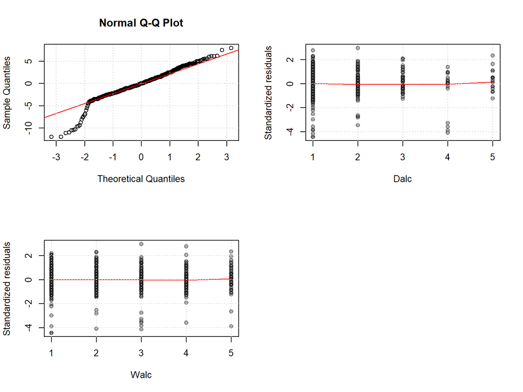

Follow-up tests for the residuals:

| Test | p-value |
| --- | --- |
| Shapiro-Wilk | 2.6693874^{-14} |
| Breusch-Pagan | 6.5075974^{-5} |

```r
shapiro.test(residuals(model2))$p.value
```

```
## [1] 2.669387e-14
```

```r
bptest(model2)$p.value
```

```
##           BP
## 6.507597e-05
```

They are not normal and heteroscedastic, so we’ll need to use White’s correction as well as adjustment for multiplicity when estimating the significance of the predictors:

```
##
## Call:
## lm(formula = G3 ~ schoolMS + schoolsupyes + studytime + failures +
##     higheryes + Dalc + Walc, data = combined_df)
##
## Residuals:
##     Min      1Q  Median      3Q     Max
## -12.019  -1.510  -0.017   1.495   7.991
##
## Coefficients:
##                Estimate Std. Error    t value   Pr(>|t|) Adjusted p-value
## (Intercept)   1.103e+01  5.127e-01  2.151e+01  1.185e-77              NaN
## schoolMS     -1.496e+00  2.291e-01 -6.530e+00  1.336e-10            0.000
## schoolsupyes -1.374e+00  3.536e-01 -3.885e+00  1.131e-04            0.000
## studytime     5.017e-01  1.350e-01  3.716e+00  2.198e-04            0.000
## failures     -1.509e+00  1.905e-01 -7.920e+00  1.050e-14            0.000
## higheryes     1.952e+00  3.710e-01  5.262e+00  1.949e-07            0.000
## Dalc         -2.947e-01  1.474e-01 -1.999e+00  4.601e-02            0.498
## Walc         -1.713e-01  1.074e-01 -1.594e+00  1.114e-01            0.607
##
## Residual standard error: 2.71 on 641 degrees of freedom
## Multiple R-squared:  0.3038, Adjusted R-squared:  0.2962
## F-statistic: 39.96 on 7 and 641 DF,  p-value: < 2.2e-16
```

Use wald test to compare with model 1

```
## Wald test
##
## Model 1: G3 ~ schoolMS + sexM + addressU + famsizeLE3 + PstatusT + Mjobhealth +
##     Mjobother + Mjobservices + Mjobteacher + Fjobhealth + Fjobother +
##     Fjobservices + Fjobteacher + reasonhome + reasonother + reasonreputation +
##     guardianmother + guardianother + schoolsupyes + famsupyes +
##     paidyes + activitiesyes + nurseryyes + higheryes + internetyes +
##     romanticyes + Medu + Fedu + traveltime + studytime + failures +
##     famrel + freetime + goout + Dalc + Walc + health + absences
## Model 2: G3 ~ schoolMS + schoolsupyes + studytime + failures + higheryes +
##     Dalc + Walc
##   Res.Df  Df      F   Pr(>F)
## 1    610
## 2    641 -31 1.8037 0.005323 **
## ---
## Signif. codes:  0 '***' 0.001 '**' 0.01 '*' 0.05 '.' 0.1 ' ' 1
```

The P value is significant, so at least one of the features in the model 1 is important.

Trying to bring the deleted features back one by one:

```
## Single term additions
##
## Model:
## G3 ~ schoolMS + schoolsupyes + studytime + failures + higheryes +
##     Dalc + Walc
##                  Df Sum of Sq    RSS    AIC F value   Pr(>F)
## <none>                        4708.7 1302.1
## sexM              1    27.278 4681.4 1300.4  3.7292 0.053911 .
## addressU          1    17.071 4691.6 1301.8  2.3287 0.127499
## famsizeLE3        1     8.666 4700.0 1302.9  1.1801 0.277750
## PstatusT          1     0.307 4708.3 1304.1  0.0417 0.838324
## Mjobhealth        1    19.621 4689.0 1301.4  2.6781 0.102229
## Mjobother         1    14.150 4694.5 1302.2  1.9291 0.165343
## Mjobservices      1     2.043 4706.6 1303.9  0.2779 0.598295
## Mjobteacher       1    17.084 4691.6 1301.8  2.3305 0.127354
## Fjobhealth        1     0.002 4708.7 1304.1  0.0002 0.987973
## Fjobother         1     0.264 4708.4 1304.1  0.0359 0.849831
## Fjobservices      1    11.097 4697.6 1302.6  1.5119 0.219300
## Fjobteacher       1    40.515 4668.1 1298.5  5.5546 0.018732 *
## reasonhome        1     0.000 4708.7 1304.1  0.0000 0.998320
## reasonother       1    18.402 4690.3 1301.6  2.5110 0.113547
## reasonreputation  1    23.042 4685.6 1301.0  3.1472 0.076532 .
## guardianmother    1    20.978 4687.7 1301.2  2.8640 0.091067 .
## guardianother     1     3.711 4704.9 1303.6  0.5049 0.477635
## famsupyes         1     1.135 4707.5 1304.0  0.1543 0.694545
## paidyes           1     5.957 4702.7 1303.3  0.8107 0.368259
## activitiesyes     1     3.699 4705.0 1303.6  0.5031 0.478383
## nurseryyes        1     1.033 4707.6 1304.0  0.1404 0.708026
## internetyes       1    23.605 4685.0 1300.9  3.2246 0.073011 .
## romanticyes       1    17.091 4691.6 1301.8  2.3314 0.127279
## Medu              1    47.588 4661.1 1297.5  6.5342 0.010812 *
## Fedu              1    50.860 4657.8 1297.1  6.9883 0.008405 **
## traveltime        1     2.071 4706.6 1303.8  0.2816 0.595845
## famrel            1     1.811 4706.8 1303.9  0.2463 0.619896
## freetime          1    11.974 4696.7 1302.5  1.6316 0.201947
## goout             1     0.078 4708.6 1304.1  0.0106 0.917865
## health            1    46.591 4662.1 1297.7  6.3959 0.011678 *
## absences          1    10.059 4698.6 1302.8  1.3702 0.242211
## ---
## Signif. codes:  0 '***' 0.001 '**' 0.01 '*' 0.05 '.' 0.1 ' ' 1
```

The best is the model with the Fjobteacher,Medu, Fedu,health brought back:

```r
model3 <- lm(G3 ~ schoolMS+schoolsupyes+studytime+failures+ higheryes+Dalc+ Walc+Fjobteacher+Medu+ Fedu+health , data = combined_df)
```

Residual visualization

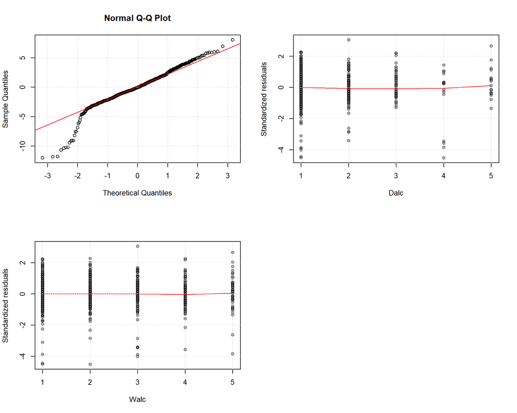

Follow-up tests for the residuals:

| Test | p-value |
| --- | --- |
| Shapiro-Wilk | 1.1057126^{-14} |
| Breusch-Pagan | 8.2119593^{-7} |

```r
shapiro.test(residuals(model3))$p.value
```

```
## [1] 1.105713e-14
```

```r
bptest(model3)$p.value
```

```
##           BP
## 8.211959e-07
```

They are not normal and heteroscedastic, so we’ll need to use White’s correction as well as adjustment for multiplicity when estimating the significance of the predictors:

```
##
## Call:
## lm(formula = G3 ~ schoolMS + schoolsupyes + studytime + failures +
##     higheryes + Dalc + Walc + Fjobteacher + Medu + Fedu + health,
##     data = combined_df)
##
## Residuals:
##      Min       1Q   Median       3Q      Max
## -12.0323  -1.3804  -0.0522   1.5347   8.0765
##
## Coefficients:
##                Estimate Std. Error    t value   Pr(>|t|) Adjusted p-value
## (Intercept)   1.103e+01  6.059e-01  1.821e+01  6.033e-60              NaN
## schoolMS     -1.373e+00  2.336e-01 -5.877e+00  6.737e-09            0.000
## schoolsupyes -1.344e+00  3.520e-01 -3.819e+00  1.469e-04            0.001
## studytime     4.971e-01  1.342e-01  3.705e+00  2.295e-04            0.001
## failures     -1.420e+00  1.899e-01 -7.476e+00  2.537e-13            0.000
## higheryes     1.819e+00  3.723e-01  4.885e+00  1.309e-06            0.000
## Dalc         -3.199e-01  1.463e-01 -2.187e+00  2.913e-02            0.563
## Walc         -1.325e-01  1.078e-01 -1.229e+00  2.195e-01            0.936
## Fjobteacher   7.663e-01  4.969e-01  1.542e+00  1.235e-01            0.819
## Medu          1.303e-01  1.253e-01  1.040e+00  2.986e-01            0.985
## Fedu          1.369e-01  1.313e-01  1.043e+00  2.976e-01            0.973
## health       -1.924e-01  7.372e-02 -2.609e+00  9.282e-03            0.073
##
## Residual standard error: 2.682 on 637 degrees of freedom
## Multiple R-squared:  0.3225, Adjusted R-squared:  0.3108
## F-statistic: 27.56 on 11 and 637 DF,  p-value: < 2.2e-16
```

```
## Wald test
##
## Model 1: G3 ~ schoolMS + schoolsupyes + studytime + failures + higheryes +
##     Dalc + Walc + Fjobteacher + Medu + Fedu + health
## Model 2: G3 ~ schoolMS + schoolsupyes + studytime + failures + higheryes +
##     Dalc + Walc
##   Res.Df Df      F    Pr(>F)
## 1    637
## 2    641 -4 4.8028 0.0008014 ***
## ---
## Signif. codes:  0 '***' 0.001 '**' 0.01 '*' 0.05 '.' 0.1 ' ' 1
```

Model 3 is significant better than model 2. However, there is still some insignificant features in model 3.

Try interaction

```
## Single term additions
##
## Model:
## G3 ~ schoolMS + schoolsupyes + studytime + failures + higheryes +
##     Dalc + Walc + Fjobteacher + Medu + Fedu + health
##                          Df Sum of Sq    RSS    AIC F value    Pr(>F)
## <none>                                4582.2 1292.5
## schoolMS:schoolsupyes     1    13.121 4569.1 1292.6  1.8265 0.1770273
## schoolMS:studytime        1     6.295 4575.9 1293.6  0.8749 0.3499449
## schoolMS:failures         1    30.553 4551.7 1290.1  4.2691 0.0392150 *
## schoolMS:higheryes        1     1.650 4580.6 1294.2  0.2291 0.6323315
## schoolMS:Dalc             1     8.307 4573.9 1293.3  1.1550 0.2829026
## schoolMS:Walc             1     9.352 4572.9 1293.2  1.3006 0.2545261
## schoolMS:Fjobteacher      1     4.953 4577.3 1293.8  0.6883 0.4070710
## schoolMS:Medu             1     0.013 4582.2 1294.5  0.0018 0.9658507
## schoolMS:Fedu             1    29.219 4553.0 1290.3  4.0815 0.0437728 *
## schoolMS:health           1     0.290 4581.9 1294.4  0.0403 0.8410408
## schoolsupyes:studytime    1    26.698 4555.5 1290.7  3.7274 0.0539720 .
## schoolsupyes:failures     1    32.678 4549.5 1289.8  4.5682 0.0329523 *
## schoolsupyes:higheryes    1    27.052 4555.2 1290.6  3.7770 0.0524014 .
## schoolsupyes:Dalc         1    30.273 4551.9 1290.2  4.2297 0.0401288 *
## schoolsupyes:Walc         1     5.024 4577.2 1293.8  0.6981 0.4037396
## schoolsupyes:Fjobteacher  1     3.929 4578.3 1293.9  0.5459 0.4602870
## schoolsupyes:Medu         1    26.746 4555.5 1290.7  3.7340 0.0537585 .
## schoolsupyes:Fedu         1    43.588 4538.6 1288.3  6.1080 0.0137178 *
## schoolsupyes:health       1    17.814 4564.4 1292.0  2.4822 0.1156354
## studytime:failures        1     4.681 4577.5 1293.8  0.6503 0.4202923
## studytime:higheryes       1     0.042 4582.2 1294.5  0.0058 0.9391397
## studytime:Dalc            1    13.655 4568.6 1292.5  1.9009 0.1684571
## studytime:Walc            1     4.905 4577.3 1293.8  0.6815 0.4093658
## studytime:Fjobteacher     1     0.916 4581.3 1294.3  0.1271 0.7215516
## studytime:Medu            1     0.032 4582.2 1294.5  0.0044 0.9469429
## studytime:Fedu            1    10.375 4571.8 1293.0  1.4432 0.2300621
## studytime:health          1     1.074 4581.1 1294.3  0.1491 0.6994953
## failures:higheryes        1     8.754 4573.5 1293.2  1.2174 0.2702850
## failures:Dalc             1     2.174 4580.0 1294.2  0.3019 0.5828703
## failures:Walc             1     2.812 4579.4 1294.1  0.3906 0.5322268
## failures:Fjobteacher      1    13.927 4568.3 1292.5  1.9389 0.1642697
## failures:Medu             1     0.002 4582.2 1294.5  0.0002 0.9883552
## failures:Fedu             1    17.861 4564.4 1291.9  2.4888 0.1151541
```

[output cut: 9 more lines]

```
## Dalc:Medu                 1   112.121 4470.1 1278.4 15.9525 7.254e-05 ***
## Dalc:Fedu                 1    74.845 4507.4 1283.8 10.5608 0.0012160 **
## Dalc:health               1     0.576 4581.6 1294.4  0.0800 0.7774535
## Walc:Fjobteacher          1    14.978 4567.2 1292.3  2.0857 0.1491778
## Walc:Medu                 1     5.620 4576.6 1293.7  0.7811 0.3771483
## Walc:Fedu                 1     0.169 4582.0 1294.5  0.0234 0.8784376
## Walc:health               1     5.134 4577.1 1293.8  0.7135 0.3986178
## Fjobteacher:Medu          1     3.444 4578.8 1294.0  0.4783 0.4894285
## Fjobteacher:Fedu          1     0.000 4582.2 1294.5  0.0000 0.9948540
## Fjobteacher:health        1    78.913 4503.3 1283.2 11.1449 0.0008918 ***
## Medu:Fedu                 1    12.807 4569.4 1292.7  1.7826 0.1823113
## Medu:health               1     0.831 4581.4 1294.4  0.1154 0.7342368
## Fedu:health               1     7.003 4575.2 1293.5  0.9735 0.3241894
## ---
## Signif. codes:  0 '***' 0.001 '**' 0.01 '*' 0.05 '.' 0.1 ' ' 1
```

Remove Medu,Fedu,Fjobteacher. Add interaction between Fjobteacher:health,Dalc:Fedu,Dalc:Medu

Add interaction to model 4

```r
model4 <- lm(G3 ~ schoolMS+schoolsupyes+studytime+failures+ higheryes+Dalc+ Walc+health+
               Fjobteacher*health+Dalc*Fedu+Dalc*Medu, data = combined_df)
```

Residual visualization

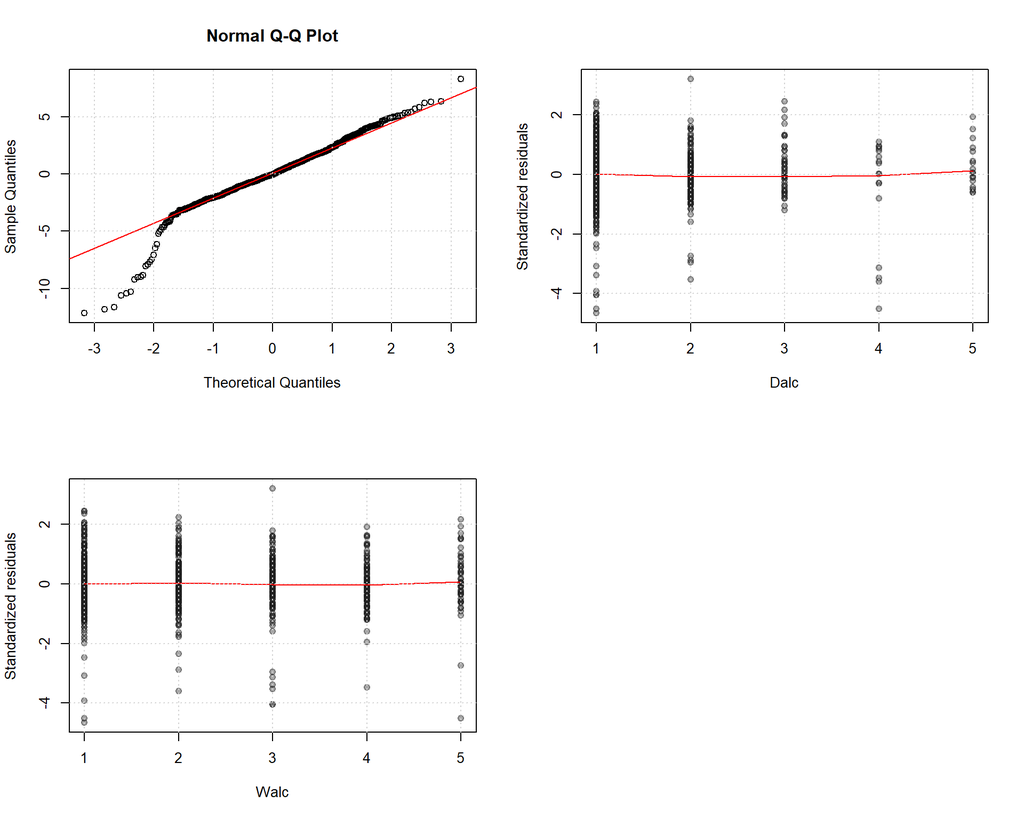

Follow-up tests for the residuals:

| Test | p-value |
| --- | --- |
| Shapiro-Wilk | 1.0310205^{-14} |
| Breusch-Pagan | 3.7145004^{-5} |

```r
shapiro.test(residuals(model4))$p.value
```

```
## [1] 1.031021e-14
```

```r
bptest(model4)$p.value
```

```
##         BP
## 3.7145e-05
```

They are not normal and heteroscedastic, so we’ll need to use White’s correction as well as adjustment for multiplicity when estimating the significance of the predictors:

```
##
## Call:
## lm(formula = G3 ~ schoolMS + schoolsupyes + studytime + failures +
##     higheryes + Dalc + Walc + health + Fjobteacher * health +
##     Dalc * Fedu + Dalc * Medu, data = combined_df)
##
## Residuals:
##     Min      1Q  Median      3Q     Max
## -12.172  -1.387  -0.049   1.574   8.309
##
## Coefficients:
##                      Estimate Std. Error    t value   Pr(>|t|) Adjusted p-value
## (Intercept)         9.285e+00  7.401e-01  1.254e+01  2.107e-32              NaN
## schoolMS           -1.396e+00  2.299e-01 -6.072e+00  2.183e-09            0.000
## schoolsupyes       -1.429e+00  3.480e-01 -4.107e+00  4.536e-05            0.001
## studytime           5.246e-01  1.321e-01  3.970e+00  7.995e-05            0.000
## failures           -1.453e+00  1.867e-01 -7.781e+00  2.934e-14            0.000
## higheryes           1.842e+00  3.665e-01  5.025e+00  6.558e-07            0.000
## Dalc                6.809e-01  2.921e-01  2.331e+00  2.008e-02            0.384
## Walc               -1.499e-01  1.065e-01 -1.408e+00  1.597e-01            0.857
## health             -1.281e-01  7.436e-02 -1.722e+00  8.549e-02            0.559
## Fjobteacher         4.556e+00  1.312e+00  3.473e+00  5.489e-04            0.001
## Fedu                2.692e-01  2.490e-01  1.081e+00  2.800e-01            0.984
## Medu                5.986e-01  2.396e-01  2.498e+00  1.274e-02            0.241
## health:Fjobteacher -1.051e+00  3.355e-01 -3.134e+00  1.806e-03            0.014
## Dalc:Fedu          -7.894e-02  1.439e-01 -5.486e-01  5.835e-01            1.000
## Dalc:Medu          -3.186e-01  1.371e-01 -2.323e+00  2.049e-02            0.310
##
## Residual standard error: 2.634 on 634 degrees of freedom
## Multiple R-squared:  0.3495, Adjusted R-squared:  0.3352
## F-statistic: 24.33 on 14 and 634 DF,  p-value: < 2.2e-16
```

Comparing to model 4,3 with Wald’s test with White’s correction:

```
## Wald test
##
## Model 1: G3 ~ schoolMS + schoolsupyes + studytime + failures + higheryes +
##     Dalc + Walc + health + Fjobteacher * health + Dalc * Fedu +
##     Dalc * Medu
## Model 2: G3 ~ schoolMS + schoolsupyes + studytime + failures + higheryes +
##     Dalc + Walc + Fjobteacher + Medu + Fedu + health
##   Res.Df Df      F    Pr(>F)
## 1    634
## 2    637 -3 6.1134 0.0004206 ***
## ---
## Signif. codes:  0 '***' 0.001 '**' 0.01 '*' 0.05 '.' 0.1 ' ' 1
```

Model 4 is significant better than model 3. However, we still see some insignificant variables.

Remove interaction between Dalc:Medu, Dalc:Medu

```r
model5 <- lm(G3 ~ schoolMS+schoolsupyes+studytime+failures+ higheryes+Dalc+ Walc+health+
               Fjobteacher*health, data = combined_df)
```

Residual visualization

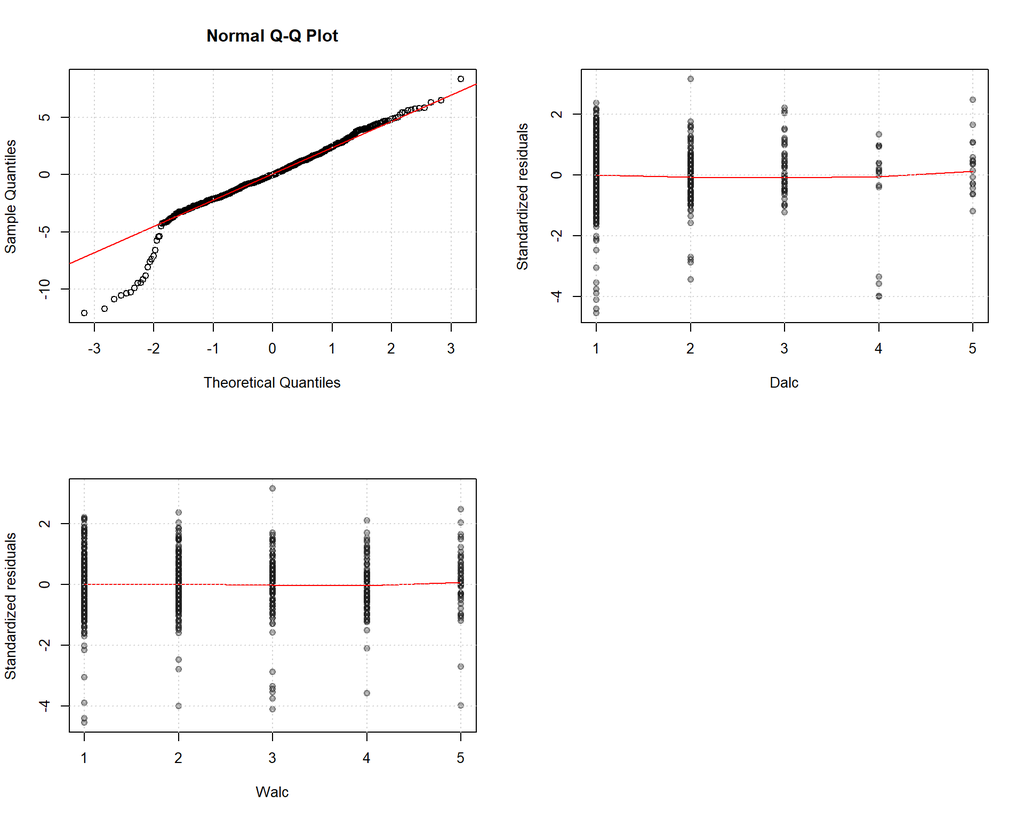

Follow-up tests for the residuals:

| Test | p-value |
| --- | --- |
| Shapiro-Wilk | 2.5997965^{-14} |
| Breusch-Pagan | 1.2358707^{-4} |

```r
shapiro.test(residuals(model5))$p.value
```

```
## [1] 2.599796e-14
```

```r
bptest(model5)$p.value
```

```
##           BP
## 0.0001235871
```

They are not normal and heteroscedastic, so we’ll need to use White’s correction as well as adjustment for multiplicity when estimating the significance of the predictors:

```
##
## Call:
## lm(formula = G3 ~ schoolMS + schoolsupyes + studytime + failures +
##     higheryes + Dalc + Walc + health + Fjobteacher * health,
##     data = combined_df)
##
## Residuals:
##      Min       1Q   Median       3Q      Max
## -12.1129  -1.4732  -0.0372   1.6284   8.3657
##
## Coefficients:
##                      Estimate Std. Error    t value   Pr(>|t|) Adjusted p-value
## (Intercept)         1.140e+01  5.629e-01  2.026e+01  7.685e-71              NaN
## schoolMS           -1.525e+00  2.269e-01 -6.723e+00  3.968e-11            0.000
## schoolsupyes       -1.497e+00  3.499e-01 -4.277e+00  2.183e-05            0.000
## studytime           5.064e-01  1.333e-01  3.799e+00  1.590e-04            0.000
## failures           -1.479e+00  1.881e-01 -7.865e+00  1.579e-14            0.000
## higheryes           1.919e+00  3.657e-01  5.249e+00  2.088e-07            0.000
## Dalc               -2.792e-01  1.457e-01 -1.917e+00  5.569e-02            0.617
## Walc               -1.513e-01  1.070e-01 -1.413e+00  1.580e-01            0.797
## health             -1.334e-01  7.522e-02 -1.773e+00  7.668e-02            0.435
## Fjobteacher         5.269e+00  1.313e+00  4.012e+00  6.731e-05            0.000
## health:Fjobteacher -1.141e+00  3.388e-01 -3.368e+00  8.031e-04            0.007
##
## Residual standard error: 2.667 on 638 degrees of freedom
## Multiple R-squared:  0.3289, Adjusted R-squared:  0.3183
## F-statistic: 31.26 on 10 and 638 DF,  p-value: < 2.2e-16
```

Comparing to model 5,4 with Wald’s test with White’s correction:

```
## Wald test
##
## Model 1: G3 ~ schoolMS + schoolsupyes + studytime + failures + higheryes +
##     Dalc + Walc + health + Fjobteacher * health + Dalc * Fedu +
##     Dalc * Medu
## Model 2: G3 ~ schoolMS + schoolsupyes + studytime + failures + higheryes +
##     Dalc + Walc + health + Fjobteacher * health
##   Res.Df Df      F    Pr(>F)
## 1    634
## 2    638 -4 4.7356 0.0009024 ***
## ---
## Signif. codes:  0 '***' 0.001 '**' 0.01 '*' 0.05 '.' 0.1 ' ' 1
```

Model 4 is still better than model 5, try to bring the deleted features back one by one

```r
add1(model5, ~ .+ Dalc:Fedu + Dalc:Medu,test="F")
```

```
## Single term additions
##
## Model:
## G3 ~ schoolMS + schoolsupyes + studytime + failures + higheryes +
##     Dalc + Walc + health + Fjobteacher * health
##           Df Sum of Sq    RSS    AIC F value Pr(>F)
## <none>                 4539.1 1284.3
## Dalc:Fedu  1   0.00385 4539.1 1286.3  0.0005 0.9815
## Dalc:Medu  1   1.82548 4537.3 1286.1  0.2563 0.6129
```

Cannot to bring any of the deleted features back. Move to use cook distance

### Cook’s distance

What are the influential observations?

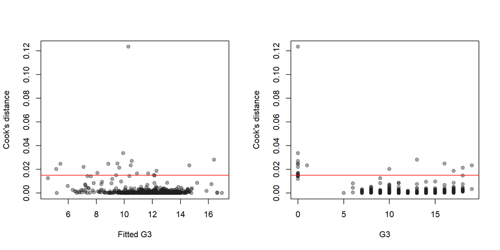

Let’s compare the coefficients of the new model with ones of the original model 5:

```
##                      All data Filtered data
## (Intercept)        11.4035519    11.0724707
## schoolMS           -1.5254614    -1.3979357
## schoolsupyes       -1.4966867    -1.6493907
## studytime           0.5063528     0.5552745
## failures           -1.4791561    -1.3622166
## higheryes           1.9194578     1.9878098
## Dalc               -0.2792465    -0.1454492
## Walc               -0.1513000    -0.1455755
## health             -0.1333806    -0.1452081
## Fjobteacher         5.2685242     5.0095150
## health:Fjobteacher -1.1411637    -1.0231705
```

Some coefficients have changed drastically, which means that the removal of influential observations did make sence.

The residuals of the new model:

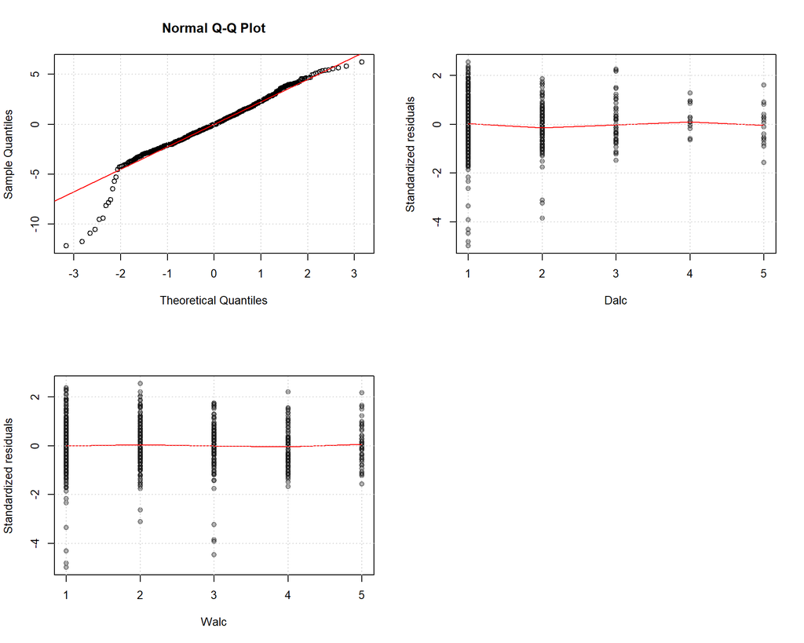

Follow-up tests for the residuals:

| Test | p-value |
| --- | --- |
| Shapiro-Wilk | 1.1696247^{-12} |
| Breusch-Pagan | 5.3075012^{-4} |

```r
shapiro.test(residuals(model6))$p.value
```

```
## [1] 1.169625e-12
```

```r
bptest(model6)$p.value
```

```
##           BP
## 0.0005307501
```

nonnormal and heteroscedastic. Significance testing with White’s correction and multiplicity adjustment:

```
##
## Call:
## lm(formula = G3 ~ schoolMS + schoolsupyes + studytime + failures +
##     higheryes + Dalc + Walc + health + Fjobteacher * health,
##     data = df2)
##
## Residuals:
##      Min       1Q   Median       3Q      Max
## -12.1915  -1.5170  -0.0247   1.5292   6.2445
##
## Coefficients:
##                      Estimate Std. Error    t value   Pr(>|t|) Adjusted p-value
## (Intercept)         1.107e+01  5.258e-01  2.106e+01  8.302e-75              NaN
## schoolMS           -1.398e+00  2.125e-01 -6.580e+00  9.984e-11            0.000
## schoolsupyes       -1.649e+00  3.333e-01 -4.949e+00  9.615e-07            0.000
## studytime           5.553e-01  1.234e-01  4.501e+00  8.078e-06            0.000
## failures           -1.362e+00  1.794e-01 -7.592e+00  1.151e-13            0.000
## higheryes           1.988e+00  3.408e-01  5.832e+00  8.771e-09            0.000
## Dalc               -1.454e-01  1.397e-01 -1.041e+00  2.983e-01            0.896
## Walc               -1.456e-01  1.006e-01 -1.447e+00  1.485e-01            0.707
## health             -1.452e-01  6.969e-02 -2.084e+00  3.759e-02            0.271
## Fjobteacher         5.010e+00  1.349e+00  3.713e+00  2.231e-04            0.000
## health:Fjobteacher -1.023e+00  3.462e-01 -2.956e+00  3.236e-03            0.000
##
## Residual standard error: 2.455 on 625 degrees of freedom
## Multiple R-squared:  0.3336, Adjusted R-squared:  0.3229
## F-statistic: 31.28 on 10 and 625 DF,  p-value: < 2.2e-16
```

## Results

The final model (#6) is build using 636 of the initial 649 datapoints; it explains 33 % of the variation in the G3:

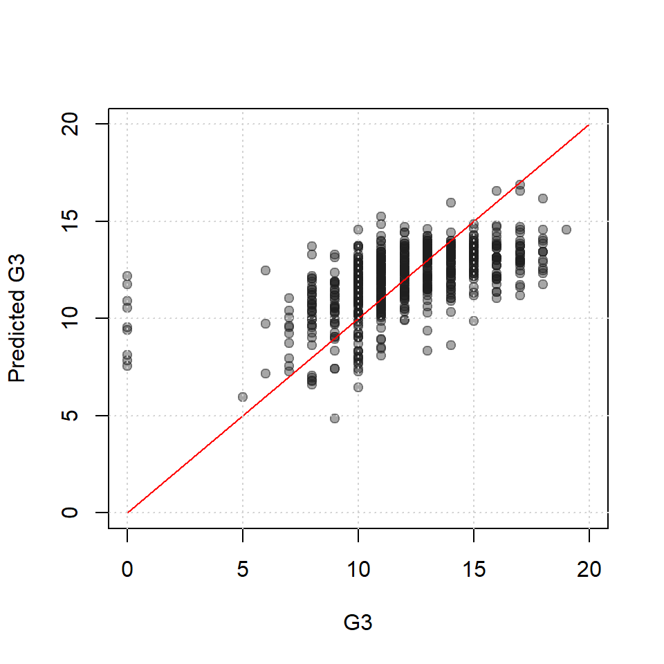

The factors we are interested in - the indicators of effect of alcohol to the final grade - have the following coefficients in the model:

```
##       Dalc       Walc
## -0.1454492 -0.1455755
```

```
##           2.5 %     97.5 %
## Dalc -0.4198430 0.12894469
## Walc -0.3431888 0.05203768
```

An unit increase in daily alcohol consumption decreases average grades by 0.14 (95% confidence interval for the decrease - [0.41, 0.13])